# Natural Language Processing

Erin M. Buchanan

2020-11-17

# What is this course about?

- Natural language processing - not only sentiment analytics
- Learning how to perform statistics on text and language (which is messy)

# What will you learn?

- Students will be able to *define* **Natural Language Processing**.
- Students will be able to **identify key concepts** *of computing with language*.
- Students will be able to **explain the relevance** *of Natural Language Processing to* **current technological needs**.
- Students will be able to **install and experiment with Natural Language Processing tools**.

# Syllabus

- You should read the syllabus for course policies and other important information.
- You will use Canvas for all course related activities.
- Let’s check those things out now.

# Writing

- You will be expected to write reports with code and text embedded.
- APA Style citations are the preferred format for crediting your sources.
- Both in-text citations and reference pages are required.
- Refer to [link](http://www.apastyle.org) if you need a review of the proper format.
- Examples:
  - Relational database systems do not lend themselves well to clustered computing; even though some RDBMS offerings have a clustered component, such as Oracle Real Application Cluster (RAC), they still rely on big hardware and a shared storage array. (Sadalage & Fowler, 2013)
  - Sadalage, P. J., & Fowler, M. (2013). NoSQL Distilled: A Brief Guide to the Emerging World of Polyglot Persistence. Upper Saddle River, NJ: Pearson Education, Inc.

# What is NLP?

- Natural language processing
- Roots in computer science, artificial intelligence, and linguistics
- Focuses on human language and how to analyze language data
- What is language? How do we deal with such a messy construct?

# Origins of NLP

- Turing Test - Intelligence (1950)
  - Chinese Room Thought Experiment by Searle (1980)
- Georgetown Experiment - Machine Translation (1954)
- NLP Systems (1960s)
  - SHRDLU
  - ELIZA
- Explosion in research given computational power increases, corpus linguistics, and machine learning

# Roots in Artificial Intelligence

- The term “artificial intelligence” was coined by John McCarthy in 1956.
- The subject has been studied for decades and one of the most elusive in Computer Science.
- AI ranges from machines that are search algorithms to the goal - capable of thinking.
- [link](https://courses.cs.washington.edu/courses/csep590/06au/projects/history-ai.pdf)

# The Turing Test

- No one can refute a computer’s ability to process logic.
- However, the question needs to be answered if the computer thinks or not.
- This gets down to the precise definition of “think”.
- It is important because their are strong oppositions as to whether or not this notion is even possible.
- The Turing test is a central, long term goal for AI research:
- Will we ever be able to build a computer that can sufficiently imitate a human to the point where a suspicious judge cannot tell the difference between human and machine?
- [link](https://en.wikipedia.org/wiki/Turing_test)

# Early 1960s ~ Baseball

- Baseball is a computer program, built in two parts, that answers questions phrased in ordinary English about stored data.
  - The program reads the question from punched cards.
  - After the words and idioms are looked up in a dictionary, the phrase structure and other syntactic facts are determined for a content analysis, which lists attribute-value pairs specifying the information given and the information requested.
  - This information was then matched to a database to find the answers.
- The program’s context was baseball games; it answers such questions as *“Where did each team play on July 7?”*

# Early 1960s ~ Eliza

- ELIZA is an early natural language processing computer program created from 1964 to 1966 at the MIT AI Lab by Joseph Weizenbaum.
  - Created to demonstrate the superficiality of communication between humans and machines.
  - It simulated conversation by using a pattern matching and substitution methodology.
  - Had no built in framework for contextualizing events.
  - Surprising number of individuals who attributed human-like feelings to the computer program, including Weizenbaum’s secretary.

# Early 1960s ~ SHRDLU

- SHRDLU is a program for understanding natural language, written by Terry Winograd at the MIT Artificial Intelligence Laboratory in 1968-70.
  - Carried on a simple dialog with a user about specific objects shown on the screen.

# Why Study NLP?

- 80% of “big data” is unstructured data
  - Images
  - Videos
  - Human language (text, recordings)
- Text Mining (text analytics, sentiment analysis, etc.)
  - Linguistic, statistical, and machine learning techniques used to derive high-quality information from text

# Traditional Approaches to Text Analytics

- Semantics
  - Readability
  - Student interest indices
  - Vocabulary
- Frequency, frequency, frequency
  - Factor/cluster analysis
  - Word clouds
  - Pages, chapters, etc.

# What are we going to do?

- Learn how to process raw text
- Learn how to tag for parts of speech
- Learn how to parse sentences and perform entity recognition
- Learn how to use dependency parsing
- Learn classification skills
- Learn sentiment analysis

# Text analytics

- NLP: use of a computer to process natural (human) language
- Computational linguistics: examining language through a computational focus
- Machine learning: using an algorithm for a machine to learn a specific task - usually how to classify or process text
- Information retrieval: looking up information based on a query, which requires text processing

# Terms to Know

- Corpus: a body of linguistic data
  - [Corpus of Contemporary American English](https://corpus.byu.edu/coca/)

[figure not shown]

# Corpora

- What can we do with a corpus?
  - Lots of stuff!
  - Commonly: part of speech tagging, stemming, lemmatization, creating and testing grammars, understanding roles and types of words
- Popular corpora:
  - Brown corpus: most overused corpus! first corpus published in a book, text in a few categories
  - LOB corpus: the British answer to the Brown corpus
  - CHILDES/TalkBank: children speeches/text, audio, video
  - WordNet: a hierarchically structured lexical database
  - Treebank: corpus for lemmatization, part of speech tagging
  - Reuters: a corpus of news articles that is often used for machine learning
  - ANC and BNC: American and British National Corpus; COCA: Corpus of Contemporary American English and Google N-gram - all the words!
  - Web/chat/email/tweets: many new corpora fall into these categories and are often hosted on kaggle

# Terms to Know

- Token: total number of words in a text
- Types: number of distinct words
- Frequency distribution: a list of all the unique tokens (types) and count of how many times they appear

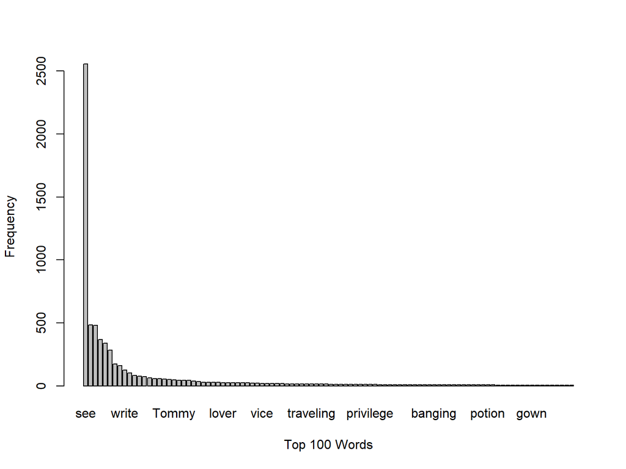

[output not shown]

```r
##r chunk
#install.packages("https://osf.io/ak7gq/download", repos = NULL, method = "libcurl", type = "source")
library(Rling)
data(ELP)
ELP <- ELP[order(ELP$SUBTLWF, decreasing = T) , ]
ELP <- ELP[1:100 , ]
barplot(ELP$SUBTLWF, names.arg = ELP$Word,
        xlab = "Top 100 Words", ylab = "Frequency")
```

# Terms to Know

- Dispersion plot: a graphical representation of the location of tokens in a text

```python
##python chunk
import nltk
from nltk.book import text4
```

```
## *** Introductory Examples for the NLTK Book ***
## Loading text1, ..., text9 and sent1, ..., sent9
## Type the name of the text or sentence to view it.
## Type: 'texts()' or 'sents()' to list the materials.
## text1: Moby Dick by Herman Melville 1851
## text2: Sense and Sensibility by Jane Austen 1811
## text3: The Book of Genesis
## text4: Inaugural Address Corpus
## text5: Chat Corpus
## text6: Monty Python and the Holy Grail
## text7: Wall Street Journal
## text8: Personals Corpus
## text9: The Man Who Was Thursday by G . K . Chesterton 1908
```

[output not shown]

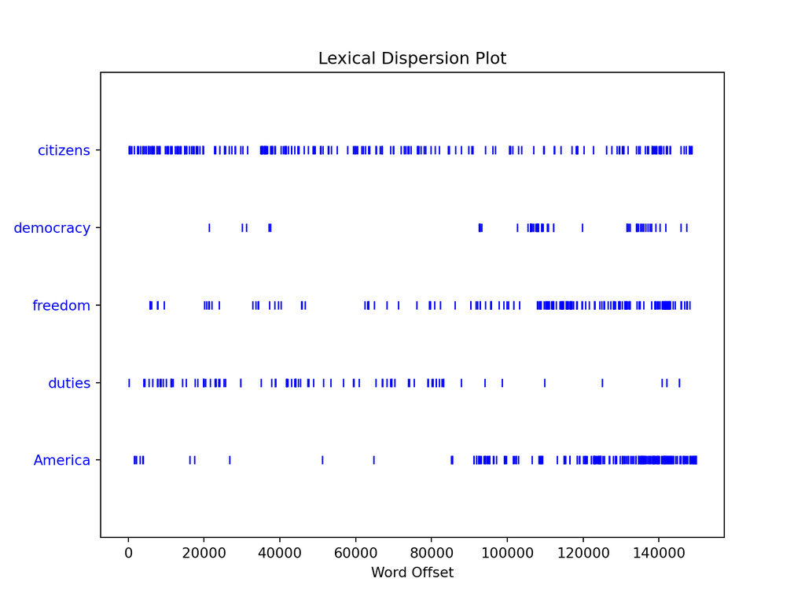

```python
text4.dispersion_plot(["citizens", "democracy", "freedom", "duties", "America"])
```

# Terms to Know

- Collocation: a sequence of words that occur together often
- n-Gram: n words that occur together

[figure not shown]

# How to Compute Language

- Basic Statistics
  - Frequency: Counts of characters, words, sentences
  - Lexical Diversity: percentage of unique word tokens
  - Lexical Dispersion: position of word tokens in the text

# How to Compute Language

- Word Sense Disambiguation
  - Determine which word was intended in a given context
    - serve: help with food or drink; hold an office; put ball into play
    - dish: plate; course of a meal; communications device
  - Contextual clues:
    - The lost children were found by the searchers (agentive)
    - The lost children were found by the mountain (locative)
    - The lost children were found by the afternoon (temporal)

# How to Compute Language

- Pronoun Resolution
  - Pronouns refers to a noun - like I/you/this
  - The noun it refers to is called the antecedent
- Examples
  - The thieves stole the paintings. They were subsequently sold.
  - The thieves stole the paintings. They were subsequently caught.
  - The thieves stole the paintings. They were subsequently found.

# How to Compute Language

- Generating Language Output
  - Question Answering
    - For example, who sold the paintings?
  - Machine Translation
    - Being able to translate from one language to another
    - Search for google translate fails
  - Spoken Dialog Systems
    - Siri, Ok Google, etc.

# How to Compute Language

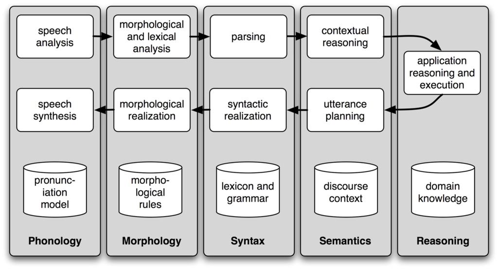

# How to Compute Language

- Textual Entailment: determining if a statement is true from a set of text input
  - Text: David Golinkin is the editor or author of eighteen books, and over 150 responsa, articles, sermons and books
  - Hypothesis: Golinkin has written eighteen books

# Final Thoughts

- In this lecture, we covered some of the basic concepts in NLP
- Additionally, how those basic concepts might be applied to future directions
- Next step: get your computer set up for the semester!